# Relationships Between Continuous Variables

Session 1

Luis F. Gómez L.

luis.gomezl@unimilitar.edu.co

Distance Learning Faculty

15 September, 2026

# Please Read Me

- This presentation is based on (Chapman & Feit, 2019, Chapter 4)
- **Purpose**
  - Understand the relationships between pairs of variables in multivariate data and examine how to visualize the relationships and compute statistics that describe their associations

# CRM system data

- **cust.id**: customer identifier
- **age**: decimal age in years
- **credit.score**: 3-digit number in [300, 900], representing the credit risk
- **email**: whether or not there is information about the customer email
- **distance.to.store**: distance in kilometers to the nearest physical store
- **online.visits**: yearly visits to the online store
- **online.trans**: yearly online orders
- **online.spend**: yearly spending in those online orders
- **store.trans**: yearly orders in physical stores
- **store.spend**: yearly spending in those physical store orders
- **sat.service**: satisfaction with service using an ordinal 5 point scale and collected using a survey
- **sat.selection**: satisfaction with product selection using an ordinal 5 point scale and collected using a survey
  - **Ordinal 5 point scale used and possible values in the survey**:
    - Extremely satisfied: 5
    - Very satisfied: 4
    - Moderately satisfied: 3
    - Very unsatisfied: 2
    - Extremely unsatisfied: 1
    - NA: customer did not response the survey

```r
customer <- read_csv(
  file = "http://goo.gl/PmPkaG"
)

customer |> head(n = 5)
```

```
# A tibble: 5 × 12
  cust.id   age credit.score email distance.to.store online.visits online.trans
    <dbl> <dbl>        <dbl> <chr>             <dbl>         <dbl>        <dbl>
1       1  22.9         631. yes                2.58            20            3
2       2  28.0         749. yes               48.2            121           39
3       3  35.9         733. yes                1.29            39           14
4       4  30.5         830. yes                5.25             1            0
5       5  38.7         734. no                25.0             35           11
# ℹ 5 more variables: online.spend <dbl>, store.trans <dbl>, store.spend <dbl>,
#   sat.service <dbl>, sat.selection <dbl>
```

- **Import data**

```r
customer <- customer |>
  mutate(
    cust.id = factor(x = cust.id, ordered = FALSE),
    email = factor(x = email, ordered = FALSE),
    online.visits = as.integer(x = online.visits),
    online.trans = as.integer(x = online.trans),
    store.trans = as.integer(x = store.trans),
    sat.service = factor(x = sat.service, ordered = TRUE),
    sat.selection = factor(x = sat.selection, ordered = TRUE)
  )

customer |> head(n = 5)
```

```
# A tibble: 5 × 12
  cust.id   age credit.score email distance.to.store online.visits online.trans
  <fct>   <dbl>        <dbl> <fct>             <dbl>         <int>        <int>
1 1        22.9         631. yes                2.58            20            3
2 2        28.0         749. yes               48.2            121           39
3 3        35.9         733. yes                1.29            39           14
4 4        30.5         830. yes                5.25             1            0
5 5        38.7         734. no                25.0             35           11
# ℹ 5 more variables: online.spend <dbl>, store.trans <int>, store.spend <dbl>,
#   sat.service <ord>, sat.selection <ord>
```

- **Transform data**

```r
customer |>
  glimpse()
```

```
Rows: 1,000
Columns: 12
$ cust.id           <fct> 1, 2, 3, 4, 5, 6, 7, 8, 9, 10, 11, 12, 13, 14, 15, 1…
$ age               <dbl> 22.89437, 28.04994, 35.87942, 30.52740, 38.73575, 42…
$ credit.score      <dbl> 630.6089, 748.5746, 732.5459, 829.5889, 733.7968, 68…
$ email             <fct> yes, yes, yes, yes, no, yes, yes, yes, no, no, no, y…
$ distance.to.store <dbl> 2.582494, 48.175989, 1.285712, 5.253992, 25.044693, …
$ online.visits     <int> 20, 121, 39, 1, 35, 1, 1, 48, 0, 14, 2, 0, 0, 108, 0…
$ online.trans      <int> 3, 39, 14, 0, 11, 1, 1, 13, 0, 6, 1, 0, 0, 26, 0, 0,…
$ online.spend      <dbl> 58.42999, 756.88008, 250.32801, 0.00000, 204.69331, …
$ store.trans       <int> 4, 0, 0, 2, 0, 0, 2, 4, 0, 3, 0, 9, 0, 3, 0, 2, 0, 2…
$ store.spend       <dbl> 140.32321, 0.00000, 0.00000, 95.91194, 0.00000, 0.00…
$ sat.service       <ord> 3, 3, NA, 4, 1, NA, 3, 2, 4, 3, 3, NA, NA, 1, NA, 3,…
$ sat.selection     <ord> 3, 3, NA, 2, 1, NA, 3, 3, 2, 2, 2, NA, NA, 2, NA, 3,…
```

- **Inspect data**

```r
customer |>
  skim()
```

- **Summarize data**
  - Ups the table is really big!!! Try it in your console to see the complete table
- **Scatterplots**
  - the tidyverse way

```r
customer |>
  ggplot() +
  geom_point(
    aes(
      x = store.spend,
      y = online.spend,
      color = email
    )
  )
```

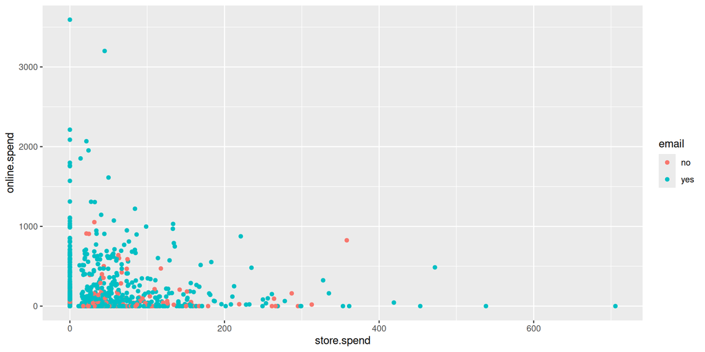

Figure 1: Using `geom_point()` to apply a geometry

- **Scatterplots**
  - the tidyverse way

```r
customer |>
  ggplot() +
  geom_point(
    aes(
      x = store.spend,
      y = online.spend,
      color = email,
      shape = email
    )
  ) +
  scale_color_manual(
    values = c("black", "green3"),
    labels = c(
      "email on file: no",
      "email on file: yes"
    )
  ) +
  scale_shape_manual(
    values = c(1, 19),
    labels = c(
      "email on file: no",
      "email on file: yes"
    )
  )
```

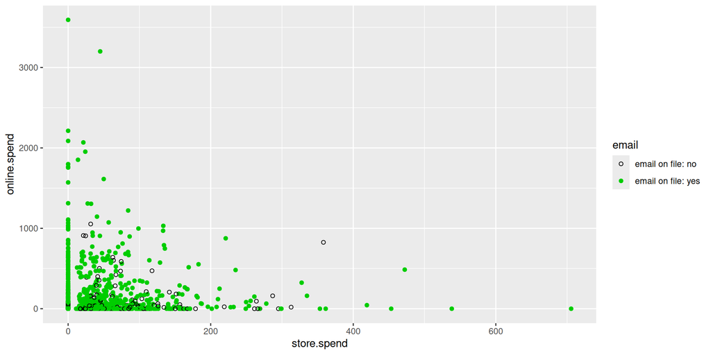

Figure 2: Using `scale_color_manual()` and `scale_shape_manual()` to modify scales for the `color` and `shape` aesthetics

- **Scatterplots**
  - the tidyverse way

```r
customer |>
  ggplot() +
  geom_point(aes(
    x = store.spend,
    y = online.spend,
    color = email,
    shape = email
  )) +
  scale_color_manual(
    values = c("black", "green3"),
    labels = c("email on file: no", "email on file: yes")
  ) +
  scale_shape_manual(
    values = c(1, 19),
    labels = c("email on file: no", "email on file: yes")
  ) +
  scale_x_continuous(
    trans = "log1p",
    breaks = c(1, 2, 5, 10, 20, 50, 100, 500)
  ) +
  scale_y_continuous(
    transform = "log1p",
    breaks = c(1, 5, 50, 500)
  )
```

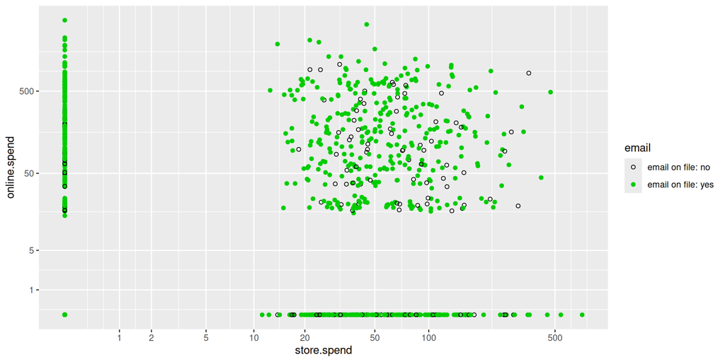

Figure 3: Using `scale_x_continuous()` and `scale_y_continuous()` to modify scales for the `x` and `y` coordinates

- **Scatterplots**
  - the tidyverse way

```r
customer |>
  ggplot() +
  geom_point(aes(
    x = store.spend,
    y = online.spend,
    color = email,
    shape = email
  )) +
  scale_color_manual(
    values = c("black", "green3"),
    labels = c("email on file: no", "email on file: yes")
  ) +
  scale_shape_manual(
    values = c(1, 19),
    labels = c("email on file: no", "email on file: yes")
  ) +
  scale_x_continuous(
    transform = "log1p",
    breaks = c(1, 2, 5, 10, 20, 50, 100, 500)
  ) +
  scale_y_continuous(trans = "log1p", breaks = c(1, 5, 50, 500)) +
  labs(
    x = "Prior 12 months in-store sales ($)",
    y = "Prior 12 months online sales ($)",
    title = "Customers as of June 2014"
  )
```

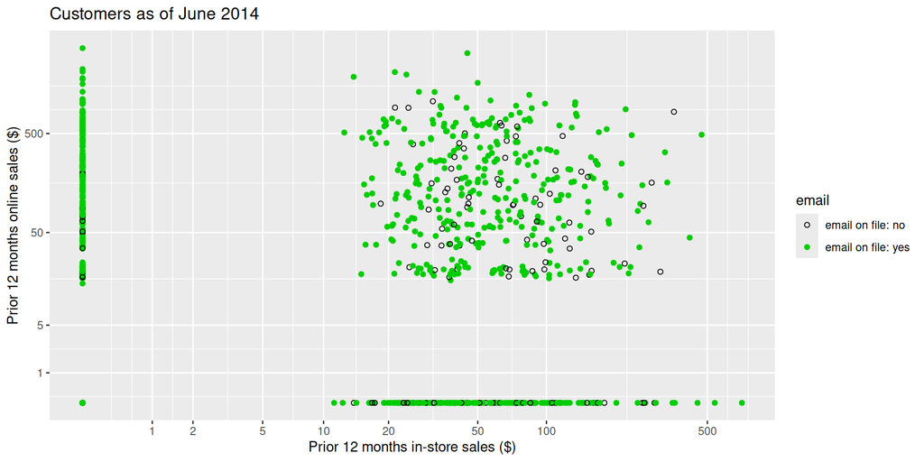

Figure 4: Using `labs()` to modify the labels

$$r_{xy} = \frac{\sum_{i=1}^n (x_i - \bar{x})(y_i - \bar{y})}{\sqrt{\sum_{i=1}^n (x_i - \bar{x})^2}\sqrt{\sum_{i=1}^n (y_i - \bar{y})^2}}
\tag{1}$$

```r
age_mean <- mean(customer$age)
age_credit.score <- mean(customer$credit.score)
numerator <- sum(
  (customer$age - age_mean) * (customer$credit.score - age_credit.score)
)
denominator <- sqrt(sum((customer$age - age_mean)^2)) *
  sqrt(sum(((customer$credit.score - age_credit.score)^2)))
pearson_corr <- numerator / denominator
pearson_corr
```

```
[1] 0.2545045
```

```r
cor(
  customer$age,
  customer$credit.score,
  method = "pearson"
)
```

```
[1] 0.2545045
```

- **Correlation Coefficients**
  - Pearson correlation coefficient for a sample
- **But don’t worry be happy!!!**
  - Use `cor`

```r
library(corrr) # Remember to install the package if it is not installed

correlation_matrix <- customer |>
  select(where(is.numeric)) |>
  correlate(
    use = "pairwise.complete.obs", # There are NA values
    method = "pearson",
    diagonal = NA
  )

correlation_matrix # Ups!!! The tibble is wide. Check out the tibble in your console
```

```
# A tibble: 8 × 9
  term             age credit.score distance.to.store online.visits online.trans
  <chr>          <dbl>        <dbl>             <dbl>         <dbl>        <dbl>
1 age         NA            0.255             0.00199       -0.0614     -0.0630
2 credit.sco…  0.255       NA                -0.0233        -0.0108     -0.00502
3 distance.t…  0.00199     -0.0233           NA             -0.0146     -0.0196
4 online.vis… -0.0614      -0.0108           -0.0146        NA           0.987
5 online.tra… -0.0630      -0.00502          -0.0196         0.987      NA
6 online.spe… -0.0607      -0.00608          -0.0204         0.982       0.993
7 store.trans  0.0242       0.0404           -0.277         -0.0367     -0.0402
8 store.spend  0.00384      0.0423           -0.241         -0.0507     -0.0522
# ℹ 3 more variables: online.spend <dbl>, store.trans <dbl>, store.spend <dbl>
```

- **Correlation matrices**
  - Pearson correlation coefficients for samples in a tibble
- **Correlation matrices**
  - Pearson correlation coefficients for samples in a tibble

```r
correlation_matrix |>
  autoplot(triangular = "lower")
```

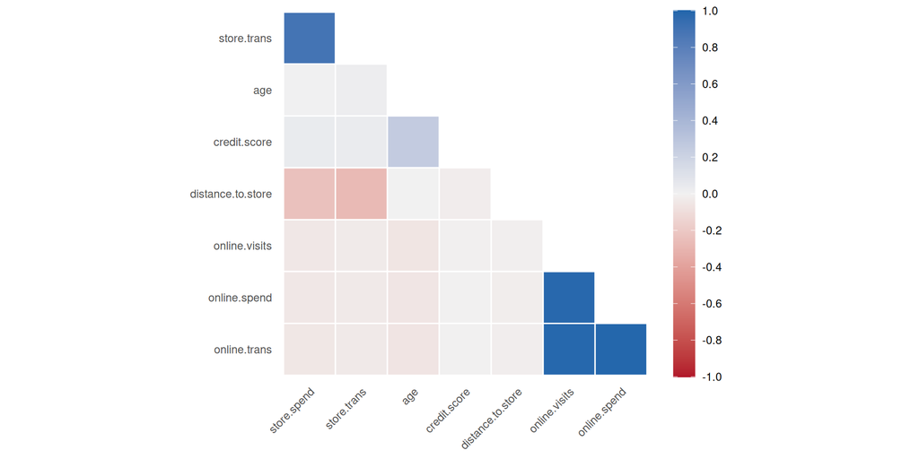

Figure 5: Visualizing a correlation matrix using `corrr`

- **Transforming variables**

```r
cor(customer$store.spend, customer$distance.to.store)
```

```
[1] -0.2414949
```

```r
customer |>
  ggplot() +
  geom_point(
    aes(
      x = distance.to.store,
      y = store.spend
    )
  )
```

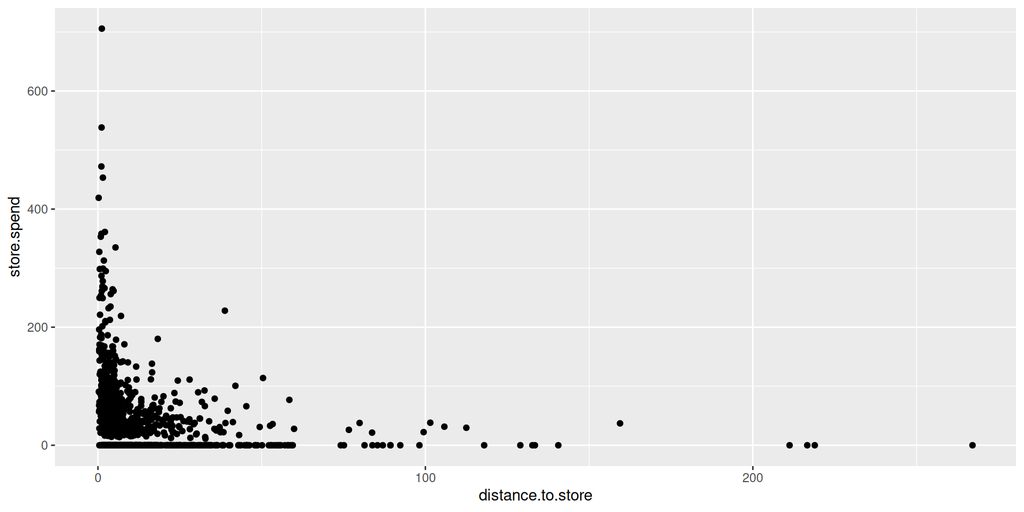

Figure 6: Scatterplot of store spending vs distance to store

- **Transforming variables**

```r
cor(customer$store.spend, 1 / sqrt(customer$distance.to.store))
```

```
[1] 0.4843334
```

```r
customer |>
  mutate(
    distance.to.store_trans = 1 / sqrt(distance.to.store)
  ) |>
  ggplot() +
  geom_point(
    aes(
      x = distance.to.store_trans,
      y = store.spend
    )
  )
```

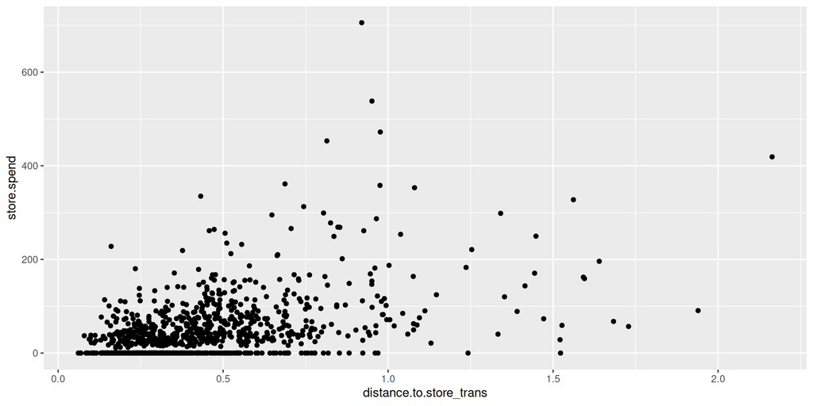

Figure 7: Scatterplot of store spending vs inverse square root distance

- **Transforming variables**
  - Understanding the logic behind inverse square root distance

```r
ggplot() +
  geom_function(
    fun = function(x) {
      1 / sqrt(x)
    }
  ) +
  labs(
    x = "Distance",
    y = "Inverse square root distance"
  )
```

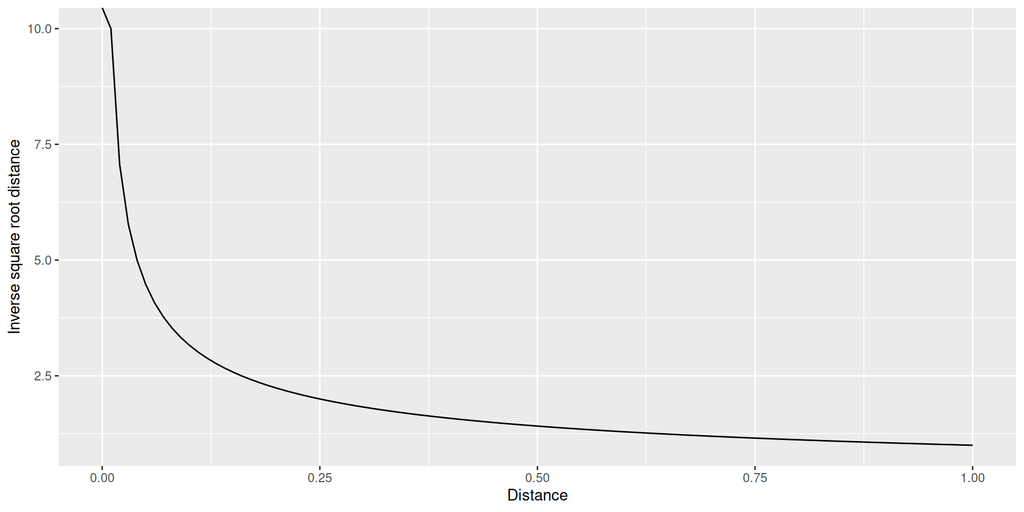

Figure 8: Using `geom_function()` to visualize inverse square root distance

- **Visualizing categorical variables**
  - **Scatterplots: the tidyverse way**

```r
customer |>
  ggplot() +
  geom_point(
    aes(
      x = sat.service,
      y = sat.selection
    )
  ) +
  labs(
    x = "Customer Satisfaction with Service",
    y = "Customer Satisfaction with Selection",
    title = "Customer as of June 2014"
  )
```

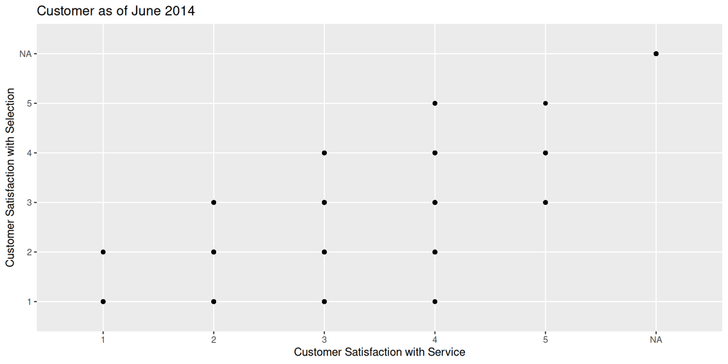

Figure 9: Using `geom_point()` with categorical variables (overplotting)

- **Visualizing categorical variables**
  - **Scatterplots: the tidyverse way**

```r
customer |>
  ggplot() +
  geom_point(
    aes(x = sat.service, y = sat.selection),
    position = position_jitter(
      width = 0.2,
      height = 0.2
    )
  ) +
  labs(
    x = "Customer Satisfaction with Service",
    y = "Customer Satisfaction with Selection",
    title = "Customer as of June 2014"
  )
```

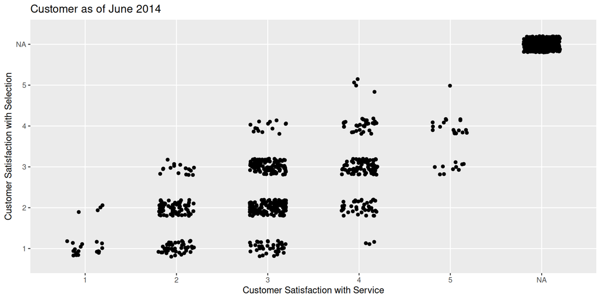

Figure 10: Using `position_jitter()` to reduce overplotting

# Acknowledgments

- To my family that supports me
- To the taxpayers of Colombia and the [**UMNG students**](https://www.umng.edu.co/estudiante) who pay my salary
- To the [**Business Science**](https://www.business-science.io/) and [**R4DS Online Learning**](https://www.rfordatasci.com/) communities where I learn [**R**](https://www.r-project.org/about.html) and [**$\pi$-thon**](https://www.python.org/about/)
- To the [**R Core Team**](https://www.r-project.org/contributors.html), the creators of [**RStudio IDE**](https://posit.co/products/open-source/rstudio/), [**Quarto**](https://quarto.org/) and the authors and maintainers of the packages [**tidyverse**](https://CRAN.R-project.org/package=tidyverse), [**skimr**](https://CRAN.R-project.org/package=skimr), [**corrr**](https://CRAN.R-project.org/package=corrr) and [**tinytex**](https://CRAN.R-project.org/package=tinytex) for allowing me to access these tools without paying for a license

# References

Chapman, C., & Feit, E. M. (2019). *R For Marketing Research and Analytics* (2nd ed. 2019). Springer International Publishing : Imprint: Springer. https://doi-org.ezproxy.umng.edu.co/10.1007/978-3-030-14316-9